# Simulated species response to suitability gradient

```r
library(dplyr)
library(ggplot2)
library(ggpubr)
setwd("D:/SyncProjects/PhD/Chapters/RQ1/Submission/SupplementaryMaterial")

dat <- read.csv("data/patches_measures75.csv")
dat85 <- read.csv("data/patches_measures85.csv")
dat$prop_filled <- dat$pa_count/dat$area
dat85$prop_filled <- dat85$pa_count/dat85$area
datSmall <- dat[dat$area <=20,]
datLarge <- dat[dat$area>20,]
datLarge$cv <- datLarge$mean/datLarge$sd
theme_Publication <- function(base_size=12, base_family="helvetica") {
      library(grid)
      library(ggthemes)
      (theme_foundation(base_size=base_size, base_family=base_family)
       + theme(plot.title = element_text(face = "bold",
                                         size = rel(1.4), hjust = 0.5),
               text = element_text(),
               panel.background = element_rect(colour = NA),
               plot.background = element_rect(colour = NA),
               panel.border = element_rect(colour = NA),
               axis.title = element_text(face = "bold",size = rel(1)),
               axis.title.y = element_text(angle=90,vjust =2),
               axis.title.x = element_text(vjust = -0.2),
               axis.text = element_text(),
               axis.line = element_line(colour="black"),
               axis.ticks = element_line(),
               panel.grid.major = element_line(colour="#f0f0f0"),
               panel.grid.minor = element_blank(),
               legend.key = element_rect(colour = NA),
               legend.position = "bottom",
               legend.direction = "horizontal",
               legend.key.size= unit(0.2, "cm"),
               legend.margin = unit(0, "cm"),
               legend.title = element_text(face="italic"),
               plot.margin=unit(c(10,5,5,5),"mm"),
               strip.background=element_rect(colour="#f0f0f0",fill="#f0f0f0"),
          ))

}
```

# Prevalence

The amount of high suitability habitat varied between landscapes by chance, ranging from 2% – 36% (µ=16%, σ=6%). All species prevalence scaled linearly with the prevalence of high suitability cells, with high fecundity species having a steeper rate of change than other species (Fig S1, S2). However, the relative prevalence varied between species depending on simulation parameters. High fecundity DP species and DO species with high dispersal probability had higher prevalence than simulations with low fecundity and low dispersal probability.

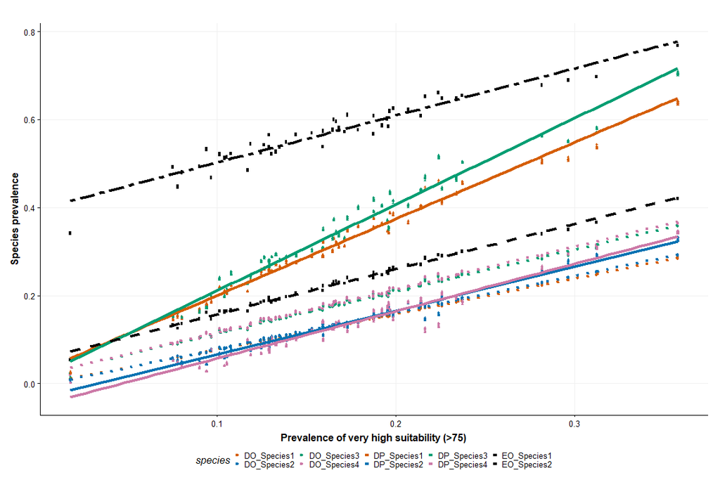

```r
prevalence75 <- read.csv("D:/SyncProjects/PhD/Chapters/RQ1/Submission/SupplementaryMaterial/data/prevalence_75.csv")
prevalence85 <- read.csv("D:/SyncProjects/PhD/Chapters/RQ1/Submission/SupplementaryMaterial/data/prevalence_85.csv")
landscape75 <- read.csv("D:/SyncProjects/PhD/Chapters/RQ1/Submission/SupplementaryMaterial/data/landscape_metrics75.csv")
landscape85 <- read.csv("D:/SyncProjects/PhD/Chapters/RQ1/Submission/SupplementaryMaterial/data/landscape_metrics85.csv")
prev_ls75 <- prevalence75 %>% full_join(landscape75,by=c("ls"="ls"))
prev_ls85 <- prevalence85 %>% full_join(landscape85,by=c("ls"="ls"))

prev_ls75 %>% ggplot(aes(y=prevalence,x=total_area/160000,color=species,linetype=species))+
  geom_point(aes(color=species,shape=species),size = 1)+
  geom_smooth(method='lm',se=FALSE,size=1.5)+
  scale_linetype_manual(values=c("dotted", "dotted","dotted", "dotted","solid", "solid","solid","solid","twodash", "dashed"))+
  scale_shape_manual(values=c(16,16,16,16,17,17,17,17,15,15))+
  scale_colour_manual(values = c("#D55E00", "#0072B2", "#009E73","#CC79A7","#D55E00", "#0072B2", "#009E73","#CC79A7","black","black"))+
   ylab("Species prevalence") + xlab("Prevalence of very high suitability (>75)")+theme_Publication()
```

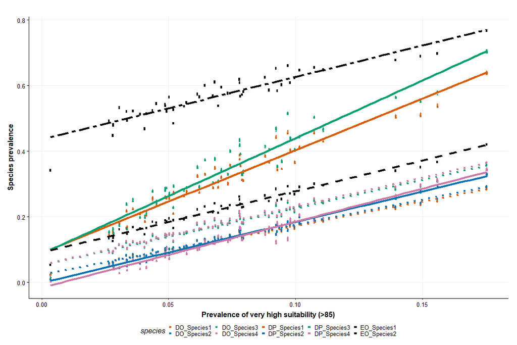

```r
prev_ls85 %>% ggplot(aes(y=prevalence,x=total_area/160000,color=species,linetype=species))+
  geom_point(aes(color=species,shape=species),size = 1)+
  geom_smooth(method='lm',se=FALSE,size=1.5)+
  scale_linetype_manual(values=c("dotted", "dotted","dotted", "dotted","solid", "solid","solid","solid","twodash", "dashed"))+
  scale_shape_manual(values=c(16,16,16,16,17,17,17,17,15,15))+
  scale_colour_manual(values = c("#D55E00", "#0072B2", "#009E73","#CC79A7","#D55E00", "#0072B2", "#009E73","#CC79A7","black","black"))+
   ylab("Species prevalence") + xlab("Prevalence of very high suitability (>85)")+theme_Publication()
```